# Generative Adversarial Networks

[link](https://arxiv.org/pdf/1701.00160.pdf)

*Generative Adversarial Networks* are the next category of models we will discuss. But before we proceed, let us briefly recall the basics of generative modelling. The most common approach is to use *Maximum Likelihood Estimation* approach to train the following model:

$$\theta^* = \underset{\theta}{\operatorname{argmax}} \sum_{i=1}^n \log p_{model}(x_i|z_i;\theta)$$

which is equivalent to:

$$\theta^* = \underset{\phi}{\operatorname{argmin}}d_{KL}(p_{data}(x)||p_{model}(x|z; \theta))$$

However, we cannot solve this problem directly, the real distribution $p(x)$ is unknown, thus we must assume its explicit form $q_{\phi}(x|z)$. This is the biggest drawback of MLE density estimation; by using a prior $q_{\phi}(x|z)$ we introduce a bias to the model, that might skew the results and decrease a overall quality of generated output.

GANs are models that do not require an explicit definition of the data distribution. Generative process is indirect and based on a simple, yet effective idea: instead of building one model that fits some probability distribution to the empirical data, we will use two models. **Generator** $\tilde{x} = G(Z;\theta)$, which generates new observations based on the latent vector $z$ and **Discriminator** $D(x,\tilde{x};\psi)$, which tries to distinguish real observations $x$ from fake ones $\tilde{x}$ generated by the generator.

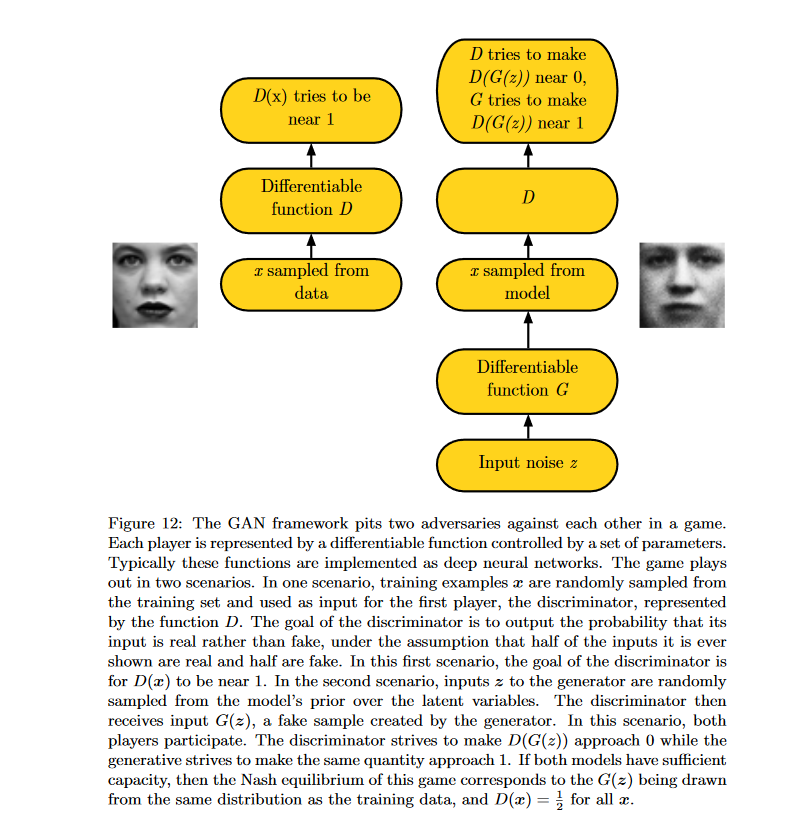

Generative Adversarial Networks have some significant advantages over other categories of generative models:

- Samples produced by GANs are regarded as having better quality than outputs of other methods.
- GANs require far fewer assumptions than other classes of generative models; neither prior probability distribution nor the Markov chain sampling is needed.
- As a result, GANs can estimate non-trivial probability distributions without introducing a bias.
- GANs are semi-supervised - discriminator is trained to classify the observations, thus it could be later used to solve other tasks.

Because we simultaneously build two models, that compete against each other, the training of Generative Adversarial Networks requires different conceptualization compared to the other neural networks.

Discriminator training is intuitive; the goal of the discriminator is to label data $x$ as real and the output of generator $\tilde{x}$ as fake. Thus, discriminator's loss is just the standard cross-entropy:

$$ J_D(\theta,\psi) =- E_{x \sim p_{data}}\log D(x) -E_z \log (1 - D(G(z)) $$

Generator's loss is far less trivial. Generative Adversarial Networks are based on the concepts drawn from the **game theory**. During the training, the discriminator tries to distinguish real data from fake one, whereas the generator tries to deceive the discriminator. Thus, generator loss is equal to:

$$J_G(\theta,\psi) = - J_D(\theta, \psi)$$

As a result, GANs training is a form of two player's **zero-sum game** where the player (discriminator or generator) wins when it maximizes its utility $U(\theta,\psi) = - J_D(\theta, \psi)$. The goal is to find the **Nash equilibrium** of such a game, by John von Neumann's **Minimax theorem** we know that equilibrium is in the following saddle point:

$$\theta^* = \operatorname{arg} \underset{\theta}{\operatorname{min}} \underset{\psi}{\operatorname{max}}U(\theta,\psi)$$

From the probability theory perspective, finding the Nash equilibrium of this game is equivalent to minimizing the **Jensen-Shannon divergence**.

The unique form of Generative Adversarial Networks has some advantages, but it also introduces some unique challenges:

- equilibrium is a saddle point; as a result, an optimization problem is far harder to solve than finding a regular extremum.
- the learning goals are to minimize the entropy of the discriminator and maximize the entropy of the generator; when one of the goals is reached too early the model will not be able to improve anymore.
- GANs usually do not converge to the optimal solution, but rather oscillate around it; the cause is the coordination of two separated loss functions during the training.
- **mode collapse** is the most common form of non-convergence encountered in the GANs. Mode collapse is a scenario when the generator learns to map several different input $z$ values to the same output point.

The aforementioned problems can be overcome (at least partially) by modifying the generator loss function:

- instead of the generator minimizing the log-probability of the discriminator being correct, the generator maximizes the log-probability of the discriminator being mistaken (this heuristic is called a **non-saturating game**): $$ J_G(\theta,\psi) =- \dfrac{1}{2}E_{z}\log D(G(z))$$
- or by solving the so-called **maximum likelihood game** - in this case generator's loss simplifies to the form: $$ J_G(\theta,\psi) =- \dfrac{1}{2}E_{z}\exp (\sigma^{-1}( D(G(z))))$$